# Part II - Prosper Loan DataSet: Studying the impacts of Creditworthiness on loans

## Investigation Overview

In this presentation, i intend to showcase the relevance of `Credit Grade` on key metrics of the prosper dataset such as the Loan Amount, Rate of Intrest and Outcome of the loan.

## Dataset Overview and Executive Summary

The dataset we are working with contains over 113,937 records between 2005 and 2014 of loans along with details such as loan amount, intrest rates and loan outcome statuses which are integral to the decision maing process.

> **Rubric Tip**: The key insights can be in a bulleted or numbered list for ease of review.

```python
# importing important packages
import numpy as np
import pandas as pd
import matplotlib.pyplot as plt
import seaborn as sns
import scipy
import warnings
import scipy.stats as stats

warnings.filterwarnings('ignore')
pd.set_option('display.max_columns', None)
pd.set_option('display.max_rows', None)
```

```python
data = pd.read_csv(r"C:\Users\frase\Desktop\Data Science\Udacity\Udacity Data Analyst\Module 4\df.csv")
```

```python
df = data.copy()
```

```python
grade_order = ['AA', 'A', 'B', 'C', 'D', 'E', 'HR']
df['CreditGrade'] = pd.Categorical(df['CreditGrade'], categories=grade_order, ordered=True)
```

## Loan Outcomes by Credit Grade: Completed vs. Charged Off

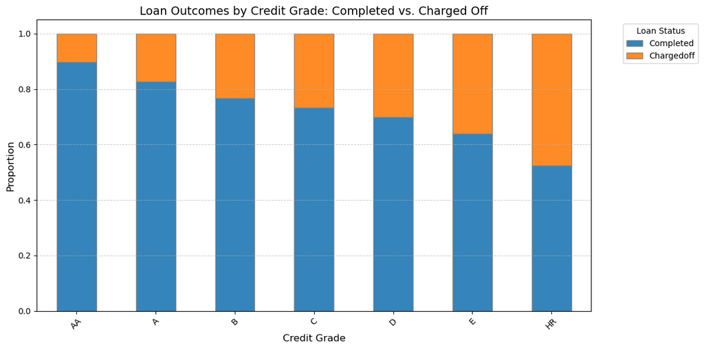

```python
df1 = df[df['LoanStatus'].isin(['Completed', 'Chargedoff'])]
status_distribution = df1.groupby(['CreditGrade', 'LoanStatus']).size().unstack(fill_value=0)
status_distribution_percentage = status_distribution.div(status_distribution.sum(axis=1), axis=0)
status_distribution_percentage = status_distribution_percentage[['Completed', 'Chargedoff']]

fig, ax = plt.subplots(figsize=(12, 6))
status_distribution_percentage.plot(kind='bar',stacked=True,alpha=0.9,edgecolor='grey',ax=ax)

ax.set_title('Loan Outcomes by Credit Grade: Completed vs. Charged Off', fontsize=14)
ax.set_xlabel('Credit Grade', fontsize=12)
ax.set_ylabel('Proportion', fontsize=12)
ax.set_xticklabels(status_distribution_percentage.index, rotation=45, fontsize=10)  # Set tick labels directly
ax.legend(title='Loan Status', bbox_to_anchor=(1.05, 1), loc='upper left')
ax.grid(axis='y', linestyle='--', linewidth=0.7, alpha=0.7)

plt.tight_layout()
plt.show()
```

```python
proportions_table = status_distribution_percentage.reset_index()
proportions_table.rename(columns={'Completed': 'Completed Proportion', 'Chargedoff': 'Charged Off Proportion'}, inplace=True)
print(proportions_table)
```

```
LoanStatus CreditGrade  Completed Proportion  Charged Off Proportion
0                   AA              0.897521                0.102479
1                    A              0.826460                0.173540
2                    B              0.766684                0.233316
3                    C              0.733686                0.266314
4                    D              0.699485                0.300515
5                    E              0.639482                0.360518
6                   HR              0.524866                0.475134
```

## Loan Amount Distribution by Credit Grade: Trends, Anomalies, and Data Concentration

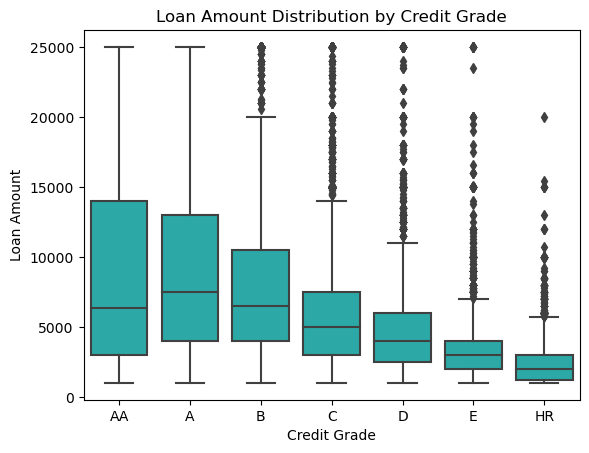

```python
sns.boxplot(x='CreditGrade', y='LoanAmount', data=df, color="#17BEBB")
plt.title('Loan Amount Distribution by Credit Grade')
plt.xlabel('Credit Grade')
plt.ylabel('Loan Amount')
plt.show()
```

```python
summary_stats = df.groupby('CreditGrade')['LoanAmount'].describe()
summary_stats = summary_stats[['mean', 'std', 'min', '25%', '50%', '75%', 'max']]
summary_stats = summary_stats.round(0).astype(int)
summary_stats
```

| CreditGrade | mean | std | min | 25% | 50% | 75% | max |
| --- | --- | --- | --- | --- | --- | --- | --- |
| AA | 9144 | 7501 | 1000 | 3000 | 6323 | 14000 | 25000 |
| A | 9292 | 7001 | 1000 | 4000 | 7500 | 13000 | 25000 |
| B | 8313 | 5901 | 1000 | 4000 | 6500 | 10500 | 25000 |
| C | 6101 | 4602 | 1000 | 3000 | 5000 | 7500 | 25000 |
| D | 4786 | 3658 | 1000 | 2500 | 4000 | 6000 | 25000 |
| E | 3392 | 2635 | 1000 | 1990 | 3000 | 4000 | 25000 |
| HR | 2454 | 1619 | 1000 | 1200 | 2000 | 3000 | 20000 |

## Loan Amount vs Borrower Rate Across Credit Grades

CHecking overall, The Loan amount and Borroer Rate have correlation of -0.32. However, when data is segmented by **`Credit Grade`**, the relationships between Loan Amount and Borrower Rate show distinct patterns. **Higher Grades (AA, A, B)**: Exhibit a **positive relationship** between Loan Amount and Borrower Rate, potentially reflecting specific borrowing dynamics for individuals with higher credit grades. **Lower Grades (C, D, E, HR)**: Concentrated in the **low loan amount - high borrower rate** regions, creating an **overall negative correlation** across all grades combined. This highlights how lower credit grades skew the aggregate data due to their disproportionate influence.

```python
df2 = df[['LoanAmount', 'BorrowerRate', 'CreditScore', 'CreditGrade']]
df2['LoanAmount'] = df2['LoanAmount'].astype('float64')
df2['BorrowerRate'] = df2['BorrowerRate'].astype('float64')
df2['CreditScore'] = df2['CreditScore'].astype('float64')
df2['CreditGrade'] = df['CreditGrade'].astype('category')
df2.dropna(subset = ['LoanAmount', 'BorrowerRate', 'CreditScore', 'CreditGrade'], inplace=True)
```

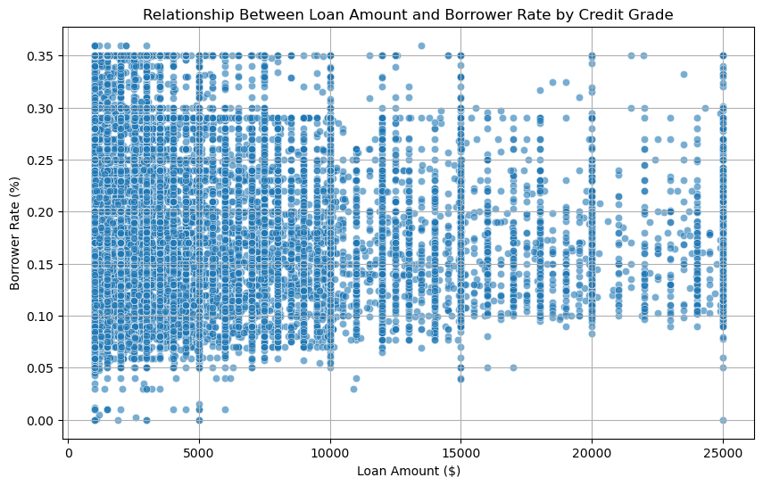

```python
plt.figure(figsize=(10, 6))
sns.scatterplot(x=df2['LoanAmount'], y=df2['BorrowerRate'], alpha=0.6)
plt.title('Relationship Between Loan Amount and Borrower Rate by Credit Grade')
plt.xlabel('Loan Amount ($)')
plt.ylabel('Borrower Rate (%)')
plt.grid(True)
plt.show()
```

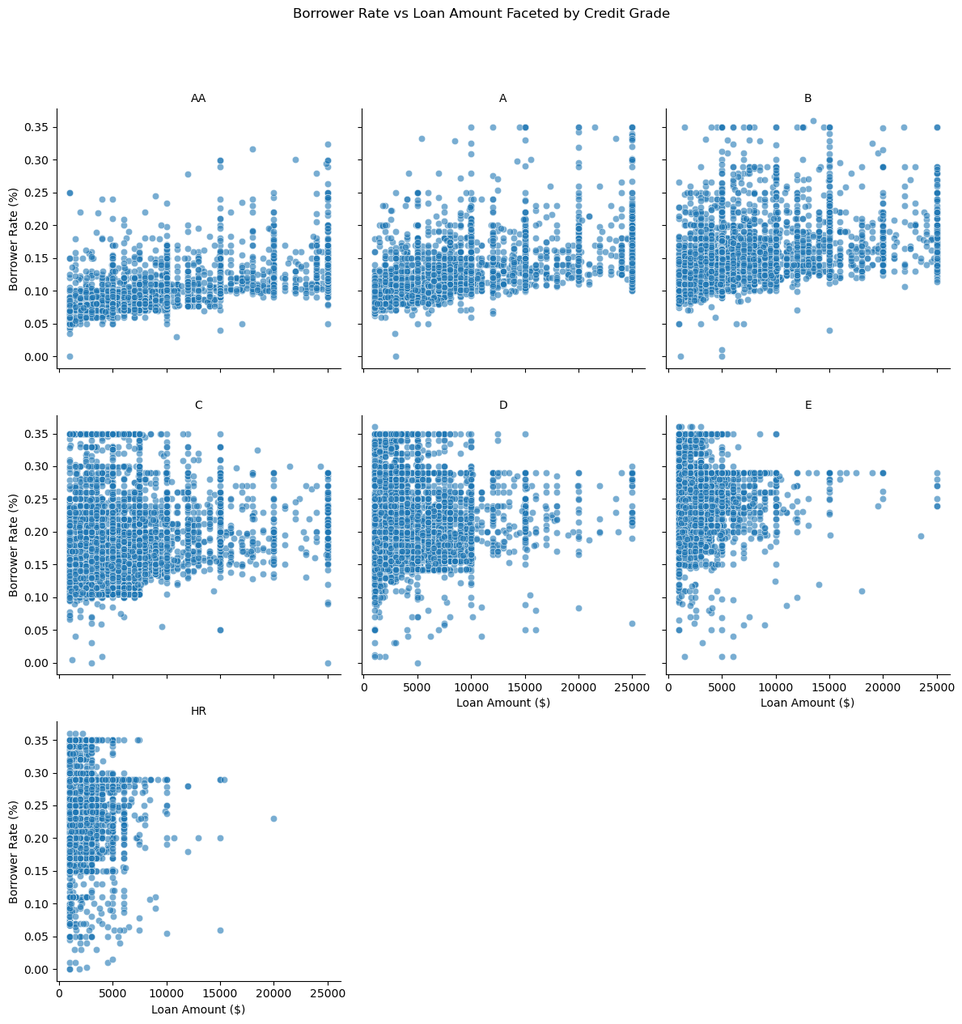

```python
g = sns.FacetGrid(df2, col="CreditGrade", col_wrap=3, height=4, sharex=True, sharey=True)
g.map(sns.scatterplot, "LoanAmount", "BorrowerRate", alpha=0.6)
g.fig.suptitle("Borrower Rate vs Loan Amount Faceted by Credit Grade", y=1.05)
g.set_axis_labels("Loan Amount ($)", "Borrower Rate (%)")
g.set_titles(col_template="{col_name}")
g.tight_layout()
plt.show()
```